# Project1

##### Information Section:

##### Full Name: Mohammad Navid Nayyem

##### Project 1

### Import Necessary Libraries

```python
# Import necessary libraries for data manipulation, visualization, and building neural networks
import os  # Import the os module for handling file paths and directories
import cv2  # Import the OpenCV library for image processing
import random  # Import the random module for random operations
import numpy as np  # Import the NumPy library for numerical operations on arrays
import seaborn as sns  # Import the seaborn library for statistical data visualization
import matplotlib.pyplot as plt  # Import the matplotlib library for plotting graphs
import tensorflow as tf  # Import the TensorFlow library for building and training neural networks
from tensorflow.keras.preprocessing.image import ImageDataGenerator  # Import ImageDataGenerator for image augmentation
from sklearn.metrics import (  # Import specific functions/classes from sklearn.metrics module
    confusion_matrix,  # Function to compute confusion matrix
    roc_curve,  # Function to plot Receiver Operating Characteristic (ROC) curve
    roc_auc_score,  # Function to compute Area Under the Curve (AUC) score for ROC curve
    classification_report  # Function to generate a text report of classification metrics
)
from sklearn.model_selection import train_test_split  # Import train_test_split function for splitting data
from tensorflow.keras.models import Sequential  # Import Sequential class for creating sequential neural network models
from tensorflow.keras.layers import (  # Import different layers to add to the model
    Conv2D,  # Convolutional layer
    MaxPooling2D,  # Max pooling layer
    Flatten,  # Flatten layer
    Dense,  # Dense (fully connected) layer
    Dropout  # Dropout layer for regularization
)
from tensorflow.keras.optimizers import Adam  # Import Adam optimizer for optimizing the model
from tensorflow.keras.callbacks import EarlyStopping  # Import EarlyStopping for early stopping during training
```

### Step 1: Data Preparation

#### This code snippet loads, preprocesses, and labels chest X-ray images from the specified directory, storing the image data and corresponding labels in lists, converting them to NumPy arrays, and normalizing the image data to the range [0, 1]. The labels of the X-ray images are given in the `NLM-MontgomeryCXRSet-ReadMe.pdf` file that contains in the dataset folder. Out of 138 X-ray images, 58 images are detected tuberculosis and 80 images are detected normal.

Download dataset from this link: https://lhncbc.nlm.nih.gov/LHC-downloads/downloads.html#tuberculosis-image-data-sets

Selected Dataset: Montgomery County CXR Set [https://data.lhncbc.nlm.nih.gov/public/Tuberculosis-Chest-X-ray-Datasets/Montgomery-County-CXR-Set/MontgomerySet/index.html]

```python
data_dir = r'C:\Users\moham\OneDrive\Desktop\MontgomerySet\CXR_png'  # Path to the directory containing the images

# Initialize lists to hold image data and labels
data = []
labels = []

# Loop through each image in the directory
for img_name in os.listdir(data_dir):
    img_path = os.path.join(data_dir, img_name)  # Get the full path of the image
    if img_name.endswith('_1.png'):
        label = 1  # Label for TB images
    elif img_name.endswith('_0.png'):
        label = 0  # Label for No-TB images
    else:
        continue  # Skip files that do not match the naming convention

    # Load the image and resize it to (100, 100)
    img = tf.keras.preprocessing.image.load_img(img_path, target_size=(100, 100))
    # Convert the image to an array
    img_array = tf.keras.preprocessing.image.img_to_array(img)
    data.append(img_array)  # Add the image array to the data list
    labels.append(label)  # Add the label to the labels list

# Convert lists to numpy arrays for easier manipulation
data = np.array(data)
labels = np.array(labels)

# Normalize the image data to the range [0, 1]
data = data / 255.0
```

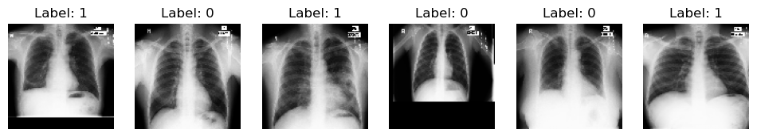

```python
# Display some images with label 0(No-TB) and 1(TB)
def display_images(images, labels, num_images_per_label=3):
    plt.figure(figsize=(12, 6))

    # Get indices of images with label 0(No-TB) and 1(TB)
    indices_label_0 = [i for i, label in enumerate(labels) if label == 0]
    indices_label_1 = [i for i, label in enumerate(labels) if label == 1]

    # Randomly select indices
    selected_indices = random.sample(indices_label_0, num_images_per_label) + random.sample(indices_label_1, num_images_per_label)
    random.shuffle(selected_indices)

    for i, idx in enumerate(selected_indices):
        plt.subplot(1, num_images_per_label * 2, i + 1)
        plt.imshow(images[idx])
        plt.title(f"Label: {labels[idx]}")
        plt.axis('off')
    plt.show()

# Display 3 images of each label 0(No-TB) and 1(TB)
display_images(data, labels)
```

### Step 2: Train-Test Split (Train-80 : Test-20)

#### This code splits the data into training and testing sets with 80% for training and 20% for testing using the `train_test_split` function from scikit-learn. The `data` variable contains the input data (features), and the `labels` variable contains the corresponding target labels. The `test_size` parameter is set to 0.2 to specify the proportion of the dataset to include in the testing set (20%). Additionally, `random_state=42` ensures reproducibility by fixing the random seed for the data splitting process.

```python
# Split the data into training and testing sets with 80% training and 20% testing
X_train, X_test, y_train, y_test = train_test_split(data, labels, test_size=0.2, random_state=42)
```

### Step 3: Neural Network Design

#### This code initializes a Sequential model with convolutional and pooling layers, followed by fully connected layers, dropout regularization, and sigmoid activation for binary classification, and compiles it using the Adam optimizer with binary cross-entropy loss and accuracy metric.

```python
# Initialize a sequential model
model = Sequential([
    # Add a convolutional layer with 32 filters, a 3x3 kernel, ReLU activation, and input shape (100, 100, 3)
    Conv2D(32, (3, 3), activation='relu', input_shape=(100, 100, 3)),
    # Add a max pooling layer with 2x2 pool size
    MaxPooling2D((2, 2)),
    # Add another convolutional layer with 64 filters and ReLU activation
    Conv2D(64, (3, 3), activation='relu'),
    # Add another max pooling layer
    MaxPooling2D((2, 2)),
    # Add another convolutional layer with 128 filters and ReLU activation
    Conv2D(128, (3, 3), activation='relu'),
    # Add another max pooling layer
    MaxPooling2D((2, 2)),
    # Flatten the output from the convolutional layers
    Flatten(),
    # Add a dense (fully connected) layer with 128 units and ReLU activation
    Dense(128, activation='relu'),
    # Add a dropout layer to reduce overfitting (drop 50% of the units)
    Dropout(0.5),
    # Add a dense layer with 1 unit and sigmoid activation for binary classification
    Dense(1, activation='sigmoid')
])

# Compile the model with Adam optimizer, binary cross-entropy loss, and accuracy metric
model.compile(optimizer=Adam(learning_rate=0.001), loss='binary_crossentropy', metrics=['accuracy'])
```

### Step 4: Model Training

#### The model has been trained using the training data and validate it using a validation split of 20%. Early stopping is used to monitor the validation loss and stop training if it does not improve for 7 epochs.

```python
# Define early stopping to monitor validation loss and stop training if it does not improve for 5 epochs
early_stopping = EarlyStopping(monitor='val_loss', patience=7, restore_best_weights=True)

# Train the model with training data, validate with a validation split of 20%, and use early stopping
history = model.fit(X_train, y_train, epochs=25, batch_size=32, validation_split=0.2, callbacks=[early_stopping])
```

```
3/3 ━━━━━━━━━━━━━━━━━━━━ 6s 444ms/step - accuracy: 0.5767 - loss: 0.6725 - val_accuracy: 0.7727 - val_loss: 0.6809
3/3 ━━━━━━━━━━━━━━━━━━━━ 1s 246ms/step - accuracy: 0.5462 - loss: 0.6986 - val_accuracy: 0.5000 - val_loss: 0.7332
3/3 ━━━━━━━━━━━━━━━━━━━━ 1s 255ms/step - accuracy: 0.6101 - loss: 0.6950 - val_accuracy: 0.5000 - val_loss: 0.6741
3/3 ━━━━━━━━━━━━━━━━━━━━ 1s 254ms/step - accuracy: 0.6204 - loss: 0.6650 - val_accuracy: 0.4545 - val_loss: 0.6700
3/3 ━━━━━━━━━━━━━━━━━━━━ 1s 247ms/step - accuracy: 0.6410 - loss: 0.6593 - val_accuracy: 0.5000 - val_loss: 0.6791
3/3 ━━━━━━━━━━━━━━━━━━━━ 1s 248ms/step - accuracy: 0.5788 - loss: 0.6546 - val_accuracy: 0.5455 - val_loss: 0.6471
3/3 ━━━━━━━━━━━━━━━━━━━━ 1s 246ms/step - accuracy: 0.5820 - loss: 0.6366 - val_accuracy: 0.5909 - val_loss: 0.6415
3/3 ━━━━━━━━━━━━━━━━━━━━ 1s 251ms/step - accuracy: 0.6325 - loss: 0.6076 - val_accuracy: 0.5455 - val_loss: 0.6321
3/3 ━━━━━━━━━━━━━━━━━━━━ 1s 250ms/step - accuracy: 0.7060 - loss: 0.5611 - val_accuracy: 0.5000 - val_loss: 0.6062
3/3 ━━━━━━━━━━━━━━━━━━━━ 1s 241ms/step - accuracy: 0.6183 - loss: 0.5680 - val_accuracy: 0.5000 - val_loss: 0.6062
3/3 ━━━━━━━━━━━━━━━━━━━━ 1s 268ms/step - accuracy: 0.7365 - loss: 0.5153 - val_accuracy: 0.6818 - val_loss: 0.5405
3/3 ━━━━━━━━━━━━━━━━━━━━ 1s 256ms/step - accuracy: 0.8327 - loss: 0.4508 - val_accuracy: 0.9091 - val_loss: 0.4806
3/3 ━━━━━━━━━━━━━━━━━━━━ 1s 255ms/step - accuracy: 0.8267 - loss: 0.3963 - val_accuracy: 0.8636 - val_loss: 0.4164
3/3 ━━━━━━━━━━━━━━━━━━━━ 1s 256ms/step - accuracy: 0.8498 - loss: 0.3685 - val_accuracy: 0.9091 - val_loss: 0.3388
3/3 ━━━━━━━━━━━━━━━━━━━━ 1s 247ms/step - accuracy: 0.9347 - loss: 0.2635 - val_accuracy: 0.9091 - val_loss: 0.4186
3/3 ━━━━━━━━━━━━━━━━━━━━ 1s 241ms/step - accuracy: 0.8864 - loss: 0.2835 - val_accuracy: 0.9091 - val_loss: 0.2973
3/3 ━━━━━━━━━━━━━━━━━━━━ 1s 251ms/step - accuracy: 0.9038 - loss: 0.2430 - val_accuracy: 0.9091 - val_loss: 0.2437
3/3 ━━━━━━━━━━━━━━━━━━━━ 1s 253ms/step - accuracy: 0.9634 - loss: 0.1409 - val_accuracy: 0.9091 - val_loss: 0.3180
3/3 ━━━━━━━━━━━━━━━━━━━━ 1s 246ms/step - accuracy: 0.9521 - loss: 0.1489 - val_accuracy: 0.9091 - val_loss: 0.2899
3/3 ━━━━━━━━━━━━━━━━━━━━ 1s 250ms/step - accuracy: 0.9734 - loss: 0.0938 - val_accuracy: 0.9091 - val_loss: 0.3462
3/3 ━━━━━━━━━━━━━━━━━━━━ 1s 260ms/step - accuracy: 0.9943 - loss: 0.0488 - val_accuracy: 0.9091 - val_loss: 0.5286
3/3 ━━━━━━━━━━━━━━━━━━━━ 1s 249ms/step - accuracy: 0.9634 - loss: 0.1097 - val_accuracy: 0.9091 - val_loss: 0.3579
3/3 ━━━━━━━━━━━━━━━━━━━━ 1s 252ms/step - accuracy: 0.9904 - loss: 0.0678 - val_accuracy: 0.9091 - val_loss: 0.3911
3/3 ━━━━━━━━━━━━━━━━━━━━ 1s 265ms/step - accuracy: 1.0000 - loss: 0.0420 - val_accuracy: 0.9091 - val_loss: 0.5656
```

### Step 5: Evaluate the Model

#### This code evaluates the trained model on the test set and calculates the test accuracy. It then prints the test accuracy as a percentage with two decimal places.

```python
# Evaluate the model on the test set and print the test accuracy
test_loss, test_accuracy = model.evaluate(X_test, y_test)
print(f"Test Accuracy: {test_accuracy * 100:.2f}%")
```

```
1/1 ━━━━━━━━━━━━━━━━━━━━ 0s 110ms/step - accuracy: 0.8571 - loss: 0.3559
Test Accuracy: 85.71%
```

### Step 6: Function to Display Image with Prediction (Binary Decision)

#### Functions are defined to display images with model predictions and to randomly select and predict images from a specified folder. This allows for visualizing the model's predictions on unseen images and assessing its performance qualitatively.

```python
# Function to display image with prediction
def display_image_with_prediction(image_path, model):
    img = cv2.imread(image_path)  # Read the image using OpenCV
    img = cv2.resize(img, (100, 100))  # Resize the image to match model input shape

    # Check if image is loaded successfully
    if img is None:
        print(f"Error: Unable to load image '{image_path}'.")
        return

    img = img.astype(np.float32) / 255.0  # Convert to float and normalize

    # Make prediction
    prediction = model.predict(np.expand_dims(img, axis=0))[0]
    if prediction >= 0.5:
        label = "TB Detected(1)"  # Label for TB detection
    else:
        label = "No-TB Detected(0)"  # Label for No-TB detection

    # Display image with prediction
    plt.imshow(cv2.cvtColor(img, cv2.COLOR_BGR2RGB))  # Convert BGR to RGB for displaying
    plt.title(f"Prediction: {label}")  # Set the title with the prediction
    plt.axis('off')  # Turn off axis
    plt.show()  # Show the image

# Function to randomly select and predict images from a folder
def predict_random_images(folder_path, model, num_images=5):
    image_files = os.listdir(folder_path)  # List all files in the folder
    random.shuffle(image_files)  # Shuffle the list of image files
    for filename in image_files[:num_images]:  # Loop through the specified number of images
        image_path = os.path.join(folder_path, filename)  # Get the full path of the image
        print(f"Filename: {filename}")  # Print the filename
        display_image_with_prediction(image_path, model)  # Display the image with prediction
```

### Step 7: Specify Folder Path and Display Predictions

#### This code specifies the folder path containing chest X-ray images and prints predictions for randomly selected images from the folder using the `predict_random_images()` function.

```
Predictions for randomly selected images:
Filename: MCUCXR_0089_0.png
1/1 ━━━━━━━━━━━━━━━━━━━━ 0s 175ms/step
```

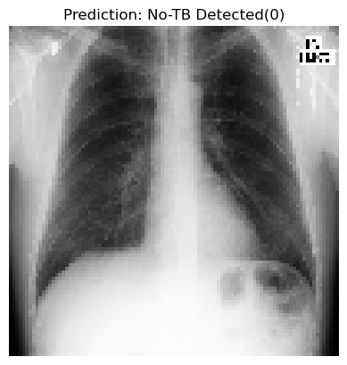

```
Filename: MCUCXR_0092_0.png
1/1 ━━━━━━━━━━━━━━━━━━━━ 0s 41ms/step
```

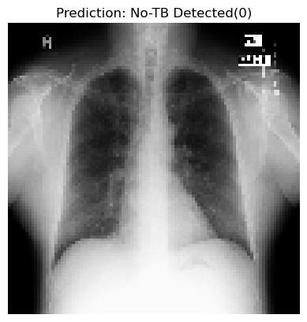

```
Filename: MCUCXR_0213_1.png
1/1 ━━━━━━━━━━━━━━━━━━━━ 0s 47ms/step
```

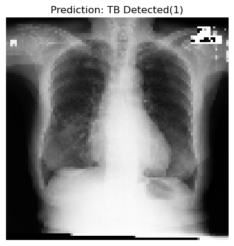

```
Filename: MCUCXR_0091_0.png
1/1 ━━━━━━━━━━━━━━━━━━━━ 0s 31ms/step
```

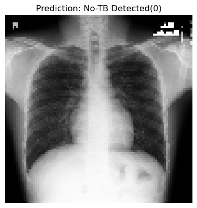

```
Filename: MCUCXR_0334_1.png
1/1 ━━━━━━━━━━━━━━━━━━━━ 0s 47ms/step
```

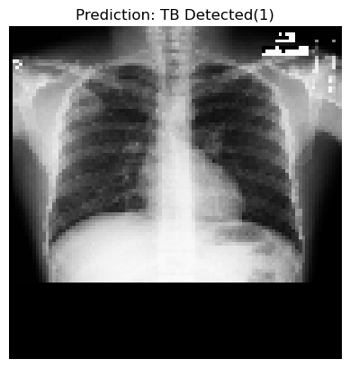

```python
# Specify the folder path
image_folder_path = r'C:\Users\moham\OneDrive\Desktop\MontgomerySet\CXR_png'

# Display predictions for randomly selected images from the image folder
print("Predictions for randomly selected images:")
predict_random_images(image_folder_path, model)  # Call the function to predict random images
```